# FinalProject141

Authors:

- Jeong, YoungHa: yhajeong@ucdavis.edu
- Patty, Lilly: lpatty@ucdavis.edu
- Prado, Alex: alxprado@ucdavis.edu
- Travers, Aurora: antravers@ucdavis.edu
- Winoto, Ivan L.: ilwinoto@ucdavis.edu

  ```
                                                                                     Abstract
  ```

  <sub>This paper aims to address the classic Stigler Diet problem by incorporating up-to-date supermarket data and nutritional information from the US Department of Agriculture. The study begins by scraping food prices and food names from dynamic supermarket websites by using Python libraries Selenium, and BeautifulSoup. To associate the scraped food items with their corresponding nutritional values, the Levenshtein distance is employed as a similarity measure between food names corresponding to nutritional values found in the US Department of Agriculture. The primal-dual path-following method, an interior-point algorithm for solving linear programming problems, is utilized to find the optimal Stigler Diet.</sub>

# 1. Introduction:

The Stigler Diet problem is a classic optimization problem in linear programming, proposed by George Stigler in 1945 for whcih he late rwon the Nobel Prize. The goal of the problem is to find the least expensive combination of foods that meets a given set of nutritional requirements. Stigler used data on food prices and nutritional content to identify a diet that would minimize the cost while satisfying the recommended daily allowances (RDAs) of various nutrients. However, it has the following limitations:

- Individual nutrient requirements can vary based on factors such as age, gender, activity level, and health status.
- It focuses solely on minimizing cost, disregarding factors such as taste, cultural preferences, and individual food aversions (like food allergies).
- It does not account for the importance of variety and a balanced diet.
- Food prices, availability, and nutritional content may change over time.
- It misses other essential nutrients or non-nutrient factors that contribute to a healthy diet.

### Case Study Safeway: Dynamic website scraped, Levenshtein distance, Optimization

Using https://www.safeway.com/, it was quickly realized that this is a dynamic website, meaning just requesting it and using BeautifulSoup would not be enough. Selenium was imported to deal with dynamic websites.

```python
import pandas as pd
import numpy as np
from selenium import webdriver
from selenium.webdriver.common.keys import Keys
from bs4 import BeautifulSoup
from selenium import webdriver
import time
import re


# Set display options to show all rows and columns (it is going to be useful later on for data cleaning)
# pd.set_option('display.max_rows', None)
# pd.set_option('display.max_columns', None)
```

```python
# THIS WAS OK IN JUST SOME ITEMS, BETTER WAYS FOUND
# Set up Selenium webdriver
driver = webdriver.Chrome()

#GETTING MEAT-SEAFOOD DATA
driver.get("https://www.safeway.com/shop/aisles/meat-seafood.3132.html")

# Wait for the dynamically loaded content to load
time.sleep(5)

# Use Selenium to scroll down the page and load more products
for i in range(3):
    driver.execute_script("window.scrollBy(0, 500);")
    time.sleep(2)

# Get the HTML of the page and parse it with BeautifulSoup
# KEEP THESE DATA SAVED
html = driver.page_source
meat_seafood = BeautifulSoup(html, 'html.parser')

# Close the browser window
driver.quit()
```

```python
# Find all products on the page
products = meat_seafood.find_all('div', {'class': 'product-title'}, {'data-name'})


meat_names = []
meat_prices = []
# Extract the name and price of each product
for product in products:
    name = product.a.get('aria-label')
    price = product.find('div', {'class': 'product-title__qty'}).text
    meat_names.append(name)
    meat_prices.append(price)
# print(meat_names, meat_prices)

df_meat_seafood = pd.DataFrame({'Meat Names': meat_names, 'Meat Prices': meat_prices})
df_meat_seafood
```

While the previous method works, it is limited in its scope for two reasons. That specific page has releases of the most popular items. Another approach was used where all the items of specific food types were kept. However, this website had to be manually loaded. A script to automatically ”click” to load more was used but it failed. Ultimately, Selenium allows for manually telling it when to fetch the data. The product’s name and respective price were found with:

```python
# GETTING ALL MEAT AND SEAFOOD

driver = webdriver.Chrome()
driver.get("https://www.safeway.com/shop/search-results.html?q=meat")

# Manually scroll down the page to the desired location
input("Scroll down to the desired location on the page, then press Enter to continue...")


# Get the HTML of the page and parse it with BeautifulSoup
# KEEP THESE DATA SAVED
html = driver.page_source
all_meat_seafood = BeautifulSoup(html, 'html.parser')

# Close the browser window
driver.quit()
```

```python
# Find all MEAT AND SEAFOOD products on the page

products_names = all_meat_seafood.find_all('a', {'data-qa': 'prd-itm-pttl'}, {'class': 'product-title__name'})
products_prices = all_meat_seafood.find_all('div', {'data-qa': 'prd-itm-pprc-qty'}, {'class': 'product-title__name'})

all_meat_seafood_names = [name.text for name in products_names]
all_meat_seafood_prices = [name.text for name in products_prices]


df_all_meat_seafood = pd.DataFrame({'All Meat & Seafood Names': all_meat_seafood_names, 'All Meat & Seafood Prices': all_meat_seafood_prices})
df_all_meat_seafood.to_csv('all_meat_seafood.csv', index=False)
```

```python
data = pd.read_csv('all_meat_seafood.csv')
print(data.head())
```

```
                            All Meat & Seafood Names All Meat & Seafood Prices
0   Ground Beef 80% Lean 20% Fat Value Pack - 3 Lbs.              ($4.99 / Lb)
1        Lauras Ground Beef 85% Lean 15% Fat - 1 Lb.              ($7.99 / Lb)
2              USDA Choice Beef For Stew - 1.50 Lbs.              ($7.99 / Lb)
3  Signature Farms Bone In Chicken Thighs Value P...              ($2.49 / Lb)
4  USDA Choice Beef Tenderloin Filet Mignon Steak...             ($23.99 / Lb)
```

```python
#GETTING Yogurt & Pudding

driver = webdriver.Chrome()
driver.get("https://www.safeway.com/shop/aisles/dairy-eggs-cheese/yogurt-pudding.3132.html")

# Manually scroll down the page to the desired location
input("Scroll down to the desired location on the page, then press Enter to continue...")


# Get the HTML of the page and parse it with BeautifulSoup
# KEEP THESE DATA SAVED
html = driver.page_source
all_yogurt_pudding = BeautifulSoup(html, 'html.parser')

# Close the browser window
driver.quit()
```

```python
# Find all Yogurt & Pudding products on the page

products_names = all_yogurt_pudding.find_all('a', {'data-qa': 'prd-itm-pttl'}, {'class': 'product-title__name'})
products_prices = all_yogurt_pudding.find_all('div', {'data-qa': 'prd-itm-pprc-qty'}, {'class': 'product-title__name'})

all_yogurt_pudding_names = [name.text for name in products_names]
all_yogurt_pudding_prices = [name.text for name in products_prices]


df_all_yogurt_pudding = pd.DataFrame({'All Yogurt & Pudding Names': all_yogurt_pudding_names, 'All Yogurt & Pudding Prices': all_yogurt_pudding_prices})
df_all_yogurt_pudding.to_csv('all_yogurt_pudding.csv', index=False)
```

```python
data = pd.read_csv('all_yogurt_pudding.csv')
print(data.head())
```

```
                          All Yogurt & Pudding Names  \
0  Yoplait Original Yogurt Low Fat Strawberry Che...
1                      Zoi Greek Lemon Cream - 32 Oz
2   FAGE Total 0% Milkfat Plain Greek Yogurt - 32 Oz
3  Oikos Triple Zero Mixed Berry... ek Yogurt - 4...
4  Yoplait Original Yogurt Low Fa... rvest Peach ...

  All Yogurt & Pudding Prices
0             ($0.16 / Ounce)
1             ($0.17 / Ounce)
2             ($0.22 / Ounce)
3             ($0.26 / Ounce)
4             ($0.15 / Ounce)
```

```python
#GETTING Cheese

driver = webdriver.Chrome()
driver.get("https://www.safeway.com/shop/aisles/dairy-eggs-cheese/cheese.3132.html")

# Manually scroll down the page to the desired location
input("Scroll down to the desired location on the page, then press Enter to continue...")


# Get the HTML of the page and parse it with BeautifulSoup
# KEEP THESE DATA SAVED
html = driver.page_source
all_cheese = BeautifulSoup(html, 'html.parser')

# Close the browser window
driver.quit()
```

```python
# Find all Cheese products on the page

products_names = all_cheese.find_all('a', {'data-qa': 'prd-itm-pttl'}, {'class': 'product-title__name'})
products_prices = all_cheese.find_all('div', {'data-qa': 'prd-itm-pprc-qty'}, {'class': 'product-title__name'})

all_cheese_names = [name.text for name in products_names]
all_cheese_prices = [name.text for name in products_prices]


df_all_cheese = pd.DataFrame({'All Cheese Names': all_cheese_names, 'All Cheese Prices': all_cheese_prices})
df_all_cheese.to_csv('all_cheese.csv', index=False)
```

```python
data = pd.read_csv('all_cheese.csv')
print(data.head())
```

```
                                    All Cheese Names All Cheese Prices
0      Lucerne Cheese Natural Medium Cheddar - 32 Oz   ($0.31 / Ounce)
1  Frigo Cheese Heads String Chee... ck 8 Count -...   ($0.55 / Ounce)
2               Lucerne Cheese Sharp Cheddar - 32 Oz   ($0.31 / Ounce)
3  Frigo Cheese Heads Cheese String 24 Count - 24 Oz   ($0.36 / Ounce)
4          Lucerne Cheese Natural Colby Jack - 32 Oz   ($0.31 / Ounce)
```

```python
#GETTING MILK & CREAM

driver = webdriver.Chrome()
driver.get("https://www.safeway.com/shop/aisles/dairy-eggs-cheese/milk-cream.3132.html")

# Manually scroll down the page to the desired location
input("Scroll down to the desired location on the page, then press Enter to continue...")


# Get the HTML of the page and parse it with BeautifulSoup
# KEEP THESE DATA SAVED
html = driver.page_source
all_milk_cream = BeautifulSoup(html, 'html.parser')

# Close the browser window
driver.quit()
```

```python
# Find all MILK & CREAM products on the page

products_names = all_milk_cream.find_all('a', {'data-qa': 'prd-itm-pttl'}, {'class': 'product-title__name'})
products_prices = all_milk_cream.find_all('div', {'data-qa': 'prd-itm-pprc-qty'}, {'class': 'product-title__name'})

all_milk_cream_names = [name.text for name in products_names]
all_milk_cream_prices = [name.text for name in products_prices]


df_all_milk_cream = pd.DataFrame({'All Cheese Names': all_milk_cream_names, 'All Cheese Prices': all_milk_cream_prices})
df_all_milk_cream.to_csv('all_milk_cream.csv', index=False)
```

```python
data = pd.read_csv('all_milk_cream.csv')
print(data.head())
```

```
                                    All Cheese Names All Cheese Prices
0          Lucerne Milk Whole 1 Gallon - 128 Fl. Oz.   ($0.05 / Fl.oz)
1    Lucerne Milk - Half Gallon (container may vary)   ($0.06 / Fl.oz)
2          Lucerne Heavy Whipping Cream - 32 Fl. Oz.   ($0.24 / Fl.oz)
3                Lactaid 2% Reduced Fat Milk - 96 Oz   ($0.08 / Fl.oz)
4  O Organics Organic Whole Milk with Vitamin D -...   ($0.06 / Fl.oz)
```

```python
#GETTING BUTTER & SOUR CREAM

driver = webdriver.Chrome()
driver.get("https://www.safeway.com/shop/aisles/dairy-eggs-cheese/butter-sour-cream.3132.html")

# Manually scroll down the page to the desired location
input("Scroll down to the desired location on the page, then press Enter to continue...")


# Get the HTML of the page and parse it with BeautifulSoup
# KEEP THESE DATA SAVED
html = driver.page_source
all_butter_sour_cream = BeautifulSoup(html, 'html.parser')

# Close the browser window
driver.quit()
```

```python
# Find all BUTTER & SOUR CREAM products on the page

products_names = all_butter_sour_cream.find_all('a', {'data-qa': 'prd-itm-pttl'}, {'class': 'product-title__name'})
products_prices = all_butter_sour_cream.find_all('div', {'data-qa': 'prd-itm-pprc-qty'}, {'class': 'product-title__name'})

all_butter_sour_cream_names = [name.text for name in products_names]
all_butter_sour_cream_prices = [name.text for name in products_prices]


df_all_butter_sour_cream = pd.DataFrame({'All Butter & Sour Cream Names': all_butter_sour_cream_names, 'All Butter & Sour Cream Prices': all_butter_sour_cream_prices})
df_all_butter_sour_cream.to_csv('all_butter_sour_cream.csv', index=False)
```

```python
data = pd.read_csv('all_butter_sour_cream.csv')
print(data.head())
```

```
                       All Butter & Sour Cream Names  \
0  Lucerne Butter Salted Sweet Cream 4 Quarters -...
1       Earth Balance Vegan Buttery Sticks - 4-16 Oz
2                    Challenge Butter Salted - 16 Oz
3     Earth Balance Olive Oil Buttery Spread - 13 Oz
4  Lucerne Unsalted Sweet Cream Butter Quarters -...

  All Butter & Sour Cream Prices
0                ($0.37 / Ounce)
1                ($0.44 / Ounce)
2                ($0.37 / Ounce)
3                ($0.54 / Ounce)
4                ($0.37 / Ounce)
```

```python
#GETTING EGGS

driver = webdriver.Chrome()
driver.get("https://www.safeway.com/shop/aisles/dairy-eggs-cheese/eggs.3132.html")

# Manually scroll down the page to the desired location
input("Scroll down to the desired location on the page, then press Enter to continue...")


# Get the HTML of the page and parse it with BeautifulSoup
# KEEP THESE DATA SAVED
html = driver.page_source
all_eggs = BeautifulSoup(html, 'html.parser')

# Close the browser window
driver.quit()
```

```python
# Find all EGGS products on the page

products_names = all_eggs.find_all('a', {'data-qa': 'prd-itm-pttl'}, {'class': 'product-title__name'})
products_prices = all_eggs.find_all('div', {'data-qa': 'prd-itm-pprc-qty'}, {'class': 'product-title__name'})

all_eggs_names = [name.text for name in products_names]
all_eggs_prices = [name.text for name in products_prices]


df_all_eggs = pd.DataFrame({'All Eggs Names': all_eggs_names, 'All Eggs Prices': all_eggs_prices})
df_all_eggs
df_all_eggs.to_csv('all_eggs.csv', index=False)
```

```python
data = pd.read_csv('all_eggs.csv')
print(data.head())
```

```
                                      All Eggs Names  All Eggs Prices
0      Lucerne Farms Eggs Cage Free Large - 18 Count  ($4.66 / Dozen)
1  Vital Farms Pasture-Raised Eggs - Large - 18 C...  ($7.33 / Dozen)
2      Lucerne Farms Eggs Large Cage Free - 12 Count  ($4.89 / Dozen)
3                  Vital Farms Eggs Large - 12 Count  ($8.99 / Dozen)
4     O Organics Organic Eggs Large Brown - 12 Count  ($5.99 / Dozen)
```

```python
#GETTING RICE

driver = webdriver.Chrome()
driver.get("https://www.safeway.com/shop/aisles/grains-pasta-sides/rice.3132.html")

# Manually scroll down the page to the desired location
input("Scroll down to the desired location on the page, then press Enter to continue...")


# Get the HTML of the page and parse it with BeautifulSoup
# KEEP THESE DATA SAVED
html = driver.page_source
all_rice = BeautifulSoup(html, 'html.parser')

# Close the browser window
driver.quit()
```

```python
# Find all RICE products on the page

products_names = all_rice.find_all('a', {'data-qa': 'prd-itm-pttl'}, {'class': 'product-title__name'})
products_prices = all_rice.find_all('div', {'data-qa': 'prd-itm-pprc-qty'}, {'class': 'product-title__name'})

all_rice_names = [name.text for name in products_names]
all_rice_prices = [name.text for name in products_prices]


df_all_rice = pd.DataFrame({'All Rice Names': all_rice_names, 'All Rice Prices': all_rice_prices})
df_all_rice.to_csv('all_rice.csv', index=False)
```

```python
data = pd.read_csv('all_rice.csv')
print(data.head())
```

```
                                      All Rice Names  All Rice Prices
0   Signature SELECT Rice Enriched Long Grain - 5 Lb     ($1.10 / Lb)
1                       Mahatma Rice Jasmine - 80 Oz     ($1.80 / Lb)
2  Signature SELECT Rice Thai Jasmine Long Grain ...     ($2.25 / Lb)
3  Signature SELECT Rice Enriched Long Grain - 32 Oz  ($0.08 / Ounce)
4  Ben's Original Parboiled Long... Dry Rice Box ...     ($2.75 / Lb)
```

```python
#GETTING STUFFING

driver = webdriver.Chrome()
driver.get("https://www.safeway.com/shop/aisles/grains-pasta-sides/stuffing-mix.3132.html")

# Manually scroll down the page to the desired location
input("Scroll down to the desired location on the page, then press Enter to continue...")


# Get the HTML of the page and parse it with BeautifulSoup
# KEEP THESE DATA SAVED
html = driver.page_source
all_stuffing = BeautifulSoup(html, 'html.parser')

# Close the browser window
driver.quit()
```

```python
# Find all STUFFING products on the page

products_names = all_stuffing.find_all('a', {'data-qa': 'prd-itm-pttl'}, {'class': 'product-title__name'})
products_prices = all_stuffing.find_all('div', {'data-qa': 'prd-itm-pprc-qty'}, {'class': 'product-title__name'})

all_stuffing_names = [name.text for name in products_names]
all_stuffing_prices = [name.text for name in products_prices]


df_all_stuffing = pd.DataFrame({'All Stuffing Names': all_stuffing_names, 'All Stuffing Prices': all_stuffing_prices})
df_all_stuffing.to_csv('all_stuffing.csv', index=False)
```

```python
data = pd.read_csv('all_stuffing.csv')
print(data.head())
```

```
                                  All Stuffing Names All Stuffing Prices
0     Stove Top Savory Herbs Stuffing Mix Box - 6 Oz     ($0.63 / Ounce)
1  Signature SELECT Stuffing Mix Chicken Flavored...     ($0.33 / Ounce)
2      Stove Top Stuffing Mix for Chicken Box - 6 Oz     ($0.63 / Ounce)
3        Stove Top Cornbread Stuffing Mix Box - 6 Oz     ($0.63 / Ounce)
4       Stove Top Stuffing Mix for Turkey Box - 6 Oz     ($0.63 / Ounce)
```

```python
#GETTING GRAINS

driver = webdriver.Chrome()
driver.get("https://www.safeway.com/shop/aisles/grains-pasta-sides/grains.3132.html")

# Manually scroll down the page to the desired location
input("Scroll down to the desired location on the page, then press Enter to continue...")


# Get the HTML of the page and parse it with BeautifulSoup
# KEEP THESE DATA SAVED
html = driver.page_source
all_grains = BeautifulSoup(html, 'html.parser')

# Close the browser window
driver.quit()
```

```python
# Find all GRAINS products on the page

products_names = all_grains.find_all('a', {'data-qa': 'prd-itm-pttl'}, {'class': 'product-title__name'})
products_prices = all_grains.find_all('div', {'data-qa': 'prd-itm-pprc-qty'}, {'class': 'product-title__name'})

all_grains_names = [name.text for name in products_names]
all_grains_prices = [name.text for name in products_prices]


df_all_grains = pd.DataFrame({'All Grains Names': all_grains_names, 'All Grains Prices': all_grains_prices})
df_all_grains
```

|  | All Grains Names | All Grains Prices |
| --- | --- | --- |
| 0 | O Organics Organic Quinoa - 16 Oz | ($0.50 / Ounce) |
| 1 | Signature SELECT Beans Pearl Barley Dry - 16 Oz | ($0.14 / Ounce) |
| 2 | O Organics Organic Quinoa Quick-Cook - 8 Oz | ($0.62 / Ounce) |
| 3 | O Organics Organic Quinoa - 64 Oz | ($6.25 / Lb) |
| 4 | Minute Ready to Serve! Rice Mi... Quinoa Cup -... | ($0.36 / Ounce) |
| 5 | Quinoa Cooked - 17.6 Oz | ($0.34 / Ounce) |
| 6 | Minute Multi-Grain Medley - 4-3 Oz | ($0.37 / Ounce) |
| 7 | Arrowhead Mills Organic Barley Pearled - 28 Oz | ($0.27 / Ounce) |
| 8 | Bob's Red Mill Organic Whole G... Free Quinoa ... | ($0.50 / Ounce) |
| 9 | Arrowhead Mills Organic Quinoa - 14 Oz | ($0.68 / Ounce) |

```python
df_all_grains.to_csv('all_grains.csv', index=False)
```

```python
#GETTING PASTA

driver = webdriver.Chrome()
driver.get("https://www.safeway.com/shop/aisles/grains-pasta-sides/pasta.3132.html")

# Manually scroll down the page to the desired location
input("Scroll down to the desired location on the page, then press Enter to continue...")


# Get the HTML of the page and parse it with BeautifulSoup
# KEEP THESE DATA SAVED
html = driver.page_source
all_pasta = BeautifulSoup(html, 'html.parser')

# Close the browser window
driver.quit()
```

```python
# Find all PASTA products on the page

products_names = all_pasta.find_all('a', {'data-qa': 'prd-itm-pttl'}, {'class': 'product-title__name'})
products_prices = all_pasta.find_all('div', {'data-qa': 'prd-itm-pprc-qty'}, {'class': 'product-title__name'})

all_pasta_names = [name.text for name in products_names]
all_pasta_prices = [name.text for name in products_prices]


df_all_pasta = pd.DataFrame({'All Pasta Names': all_pasta_names, 'All Pasta Prices': all_pasta_prices})
df_all_pasta.to_csv('all_pasta.csv', index=False)
```

```python
data = pd.read_csv('all_pasta.csv')
print(data.head())
```

```
                                     All Pasta Names All Pasta Prices
0  Signature SELECT Pasta Egg Noodles Wide Bag - ...  ($0.31 / Ounce)
1  Ancient Harvest Supergrain Pas... Spaghetti Bo...  ($0.56 / Ounce)
2    Barilla Pasta Spaghetti Gluten Free Box - 12 Oz  ($0.21 / Ounce)
3       Signature SELECT Pasta Spaghetti Box - 16 Oz  ($0.10 / Ounce)
4       Signature SELECT Pasta Spaghetti Box - 32 Oz  ($0.11 / Ounce)
```

```python
# GETTING ALL FRUITS

driver = webdriver.Chrome()
driver.get("https://www.safeway.com/shop/aisles/fruits-vegetables/fresh-fruits.3132.html")

# Manually scroll down the page to the desired location
input("Scroll down to the desired location on the page, then press Enter to continue...")


# Get the HTML of the page and parse it with BeautifulSoup
# KEEP THESE DATA SAVED
html = driver.page_source
all_fruits = BeautifulSoup(html, 'html.parser')

# Close the browser window
driver.quit()
```

```python
# Find all FRUITS products on the page

products_names = all_fruits.find_all('a', {'data-qa': 'prd-itm-pttl'}, {'class': 'product-title__name'})
products_prices = all_fruits.find_all('div', {'data-qa': 'prd-itm-pprc-qty'}, {'class': 'product-title__name'})

all_fruits_names = [name.text for name in products_names]
all_fruits_prices = [name.text for name in products_prices]


df_all_fruits = pd.DataFrame({'All Fruits Names': all_fruits_names, 'All Fruits Prices': all_fruits_prices})
df_all_fruits.to_csv('all_fruits.csv', index=False)
```

```python
data = pd.read_csv('all_fruits.csv')
print(data.head())
```

```
                        All Fruits Names All Fruits Prices
0                          Banana - Each    ($0.33 / Each)
1          Strawberries Prepacked - 1 Lb      ($4.99 / Lb)
2           Green Seedless Grapes - 2 Lb      ($3.49 / Lb)
3          Blueberries Prepacked - 18 Oz   ($0.39 / Ounce)
4  Organic Strawberries Prepacked - 1 Lb      ($5.99 / Lb)
```

```python
# GETTING ALL VEGGIES

driver = webdriver.Chrome()
driver.get("https://www.safeway.com/shop/aisles/fruits-vegetables/fresh-vegetables-herbs.3132.html")

# Manually scroll down the page to the desired location
input("Scroll down to the desired location on the page, then press Enter to continue...")


# Get the HTML of the page and parse it with BeautifulSoup
# KEEP THESE DATA SAVED
html = driver.page_source
all_veggies = BeautifulSoup(html, 'html.parser')

# Close the browser window
driver.quit()
```

Subsequently, the same was done for all food types. Additional problems occurred when getting vegetables, as some of the pricing information was missing

```python
# Find all VEGGIES products on the page

# products = all_vegies_fruits.find_all('div', {'class': 'product-title'}, {'data-name'})


products_names = all_veggies.find_all('a', {'data-qa': 'prd-itm-pttl'}, {'class': 'product-title__name'})
products_prices = all_veggies.find_all('div', {'data-qa': 'prd-itm-pprc-qty'}, {'class': 'product-title__name'})

all_veggies_names = [name.text for name in products_names]
all_veggies_prices = [name.text for name in products_prices]


# data cleaning via looking for missing price values (see below for the values found and cleaned out:

# list1 = all_veggies_names
# list2 = all_veggies_prices

# if len(list1) < len(list2):
#     list1 += [float('nan')] * (len(list2) - len(list1))
# else:
#     list2 += [float('nan')] * (len(list1) - len(list2))

# df = pd.DataFrame({'col1': list1, 'col2': list2})

# # Set display options to show all rows and columns
# pd.set_option('display.max_rows', None)
# pd.set_option('display.max_columns', None)

# print(df)

# cleaning addittional data for foods that have fuzzy price values
del all_veggies_names[69]
del all_veggies_names[157]
del all_veggies_names[229]
del all_veggies_names[293]
del all_veggies_names[346]
del all_veggies_names[363]
del all_veggies_names[411]
del all_veggies_names[431]


df_all_veggies = pd.DataFrame({'All Veggies Names': all_veggies_names, 'All Veggies Prices': all_veggies_prices})
df_all_veggies.to_csv('all_veggies.csv', index=False)
```

```python
data = pd.read_csv('all_veggies.csv')
print(data.head())
```

```
                                   All Veggies Names All Veggies Prices
0                                           Cucumber     ($1.00 / Each)
1                                     Broccoli Crown       ($3.49 / Lb)
2                                    Green Asparagus       ($4.99 / Lb)
3  Signature Farms Romaine Hearts Prepackaged - 3...    ($1.33 / Count)
4                                   Celery - 1 Bunch     ($2.99 / Each)
```

The data was subsequently converted into several CSV files and concatenated into a large CSV file, where the price per mass was calculated

```python
# List of CSV files to concatenate
csv_files = ['all_meat_seafood.csv', 'all_yogurt_pudding.csv', 'all_cheese.csv', 'all_milk_cream.csv', 'all_butter_sour_cream.csv', 'all_eggs.csv', 'all_rice.csv', 'all_grains.csv', 'all_stuffing.csv', 'all_pasta.csv', 'all_fruits.csv', 'all_veggies.csv']

# List to store DataFrames for each CSV file
dfs = []

# Loop through CSV files and read them into a DataFrame, removing headers
for csv_file in csv_files:
    df = pd.read_csv(csv_file, usecols=[0, 1], skiprows=[0], header=None)
    df.columns = ['Name', 'Price']
    dfs.append(df)

# Concatenate DataFrames into a single DataFrame
result = pd.concat(dfs)

# Save concatenated DataFrame to a new CSV file
result.to_csv('concatenated_file.csv', index=False)
```

```python
# read in the csv file
df = pd.read_csv('concatenated_file.csv')

# function to extract float from string
def extract_float(text):
    try:
        return float(re.findall('\d+\.\d+|\d+', text)[0])
    except:
        return 0

# create new column by multiplying values from columns 1 and 2
df['Mass per money'] = df['Name'].apply(lambda x: extract_float(x.split("-")[-1])).astype(float) * df['Price'].apply(extract_float).astype(float)

# create fourth column based on 'Mass per money' column criteria
df['Fourth Column'] = df['Mass per money']
df.loc[df['Mass per money'] == 0, 'Fourth Column'] = df['Price'].apply(extract_float).astype(float)

# save updated dataframe to a new csv file
df.to_csv('UPDATED_ALL_DATA.csv', index=False)
```

```python
# read in the updated csv file
df = pd.read_csv('UPDATED_ALL_DATA.csv')

# create new dataframe with only first and fourth columns
new_df = df.loc[:, ['Name', 'Fourth Column']]

# save new dataframe to a new csv file
new_df.to_csv('ALL_FOOD_PRICE.csv', index=False)
```

Unfortunately, the Safeway nutritional data has to be clicked on, one by one, to be obtained, and there are over 5k values! There is an alternative solution. The US Department of Agriculture has a data dump file ”2019-2020 FNDDS At A Glance - FNDDS Nutrient Values” in https://www.usda.gov/ where the nutritional values of many foods are listed. It would be rather obvious that the names of foods will have to match with one another

# 2. Implementing the Levenshtein Distance

The Levenshtein distance, also known as the edit distance, is a measure of the similarity between two strings. It is defined as the minimum number of single-character edits (insertions, deletions, or substitutions) required to transform one string into the other.

The Levenshtein distance between two strings can be efficiently computed using a dynamic programming algorithm. Let $s$ and $t$ be the input strings of length $m$ and $n$, respectively. We define a matrix $D$ of size $(m+1) \times (n+1)$, where $D_{i,j}$ represents the Levenshtein distance between the substrings $s_1 \ldots s_i$ and $t_1 \ldots t_j$. The matrix is initialized as follows:

\begin{align} D_{i,0} &= i, \quad 0 \leq i \leq m \\ D_{0,j} &= j, \quad 0 \leq j \leq n \end{align}

The matrix is then filled row by row using the following recurrence relation:

\begin{equation} D_{i,j} = \min \begin{cases} D_{i-1, j} + 1 \\ D_{i, j-1} + 1 \\ D_{i-1, j-1} + \delta(s_i, t_j) \end{cases} \end{equation}

Where $\delta(a, b)$ is an indicator function that returns $0$ if $a = b$ and $1$ otherwise.

After filling the matrix, the Levenshtein distance between strings $s$ and $t$ is given by the value in the bottom-right corner of the matrix:

\begin{equation} L(s, t) = D_{m,n} \end{equation}

The file '2019-2020 FNDDS At A Glance - FNDDS Nutrient Values' was slightly altered without some rows and columns into 'stigler nutrional values.csv'. The goal, then will be to pair the most similar strings with the nutritional values:

```python
import Levenshtein

#  Using the python-Levenshtein library to calculate the Levenshtein distance.

# Read CSV files
file_F = pd.read_csv('ALL_FOOD_PRICE.csv')
file_N = pd.read_csv('stigler nutrional values.csv')


# This code will read the CSV files, compare names using the Levenshtein distance,
# Function to find the most similar name
def find_most_similar_name(name_N, names_F, matched_names):
    best_match = None
    best_match_index = None
    min_distance = float('inf')

    for index, name_F in enumerate(names_F):
        if index not in matched_names:
            distance = Levenshtein.distance(name_N, name_F)

            if distance < min_distance:
                min_distance = distance
                best_match = name_F
                best_match_index = index

    return best_match, best_match_index

# Set to keep track of matched names
# keep track of the names that have already been matched in file
# ensure that a name is not matched more than once.

matched_names = set()

# Iterate through each row in file_N
# If a name in file N has a closer match to a name that has already been matched in file F,
# it will skip that name and find the next most similar name in file F that hasn't been matched yet.
for index, row in file_N.iterrows():
    name_N = row['Main food description']
    most_similar_name_F, most_similar_name_index = find_most_similar_name(name_N, file_F.iloc[:, 0], matched_names)

    # Update matched_names set
    matched_names.add(most_similar_name_F)

    # Append values from file_N to the corresponding row in file_F
    for col in file_N.columns[1:]:
        file_F.loc[file_F.iloc[:, 0] == most_similar_name_F, col] = row[col]

# Save the updated file_F to a new CSV file
file_F.to_csv('FINALoutput.csv', index=False)
```

The mostly empty rows (the names that didn't have any matches) are eliminated since nutritional values for them are not available. Additionally, because the nutritional data is in terms of 100 g per unit food, it needs to be converted either into pounds or ounces.

```python
# Amount per 100 g edible portion for energy and 64 nutrients

# Keep rows with values in all specified columns
specified_columns = list(file_N.columns[1:])
filtered_rows = file_F.dropna(subset=specified_columns)

# Save the filtered rows to a new CSV file
filtered_rows.to_csv('SECONDFINALoutput.csv', index=False)
```

```python
# This script reads the SECONDFINALoutput.csv
# file, processes the names in the "Name" column,
# extracts the numerical value and the
# letter (L or O), calculates the multiplier, and then
# multiplies the rest of the row values by
# the multiplier. The result is saved in a new CSV
# file called THIRDFINALoutput.csv.

# The first value right after "-" is a
#numerical value that needs to be converted into a float.
# The second value after "-"  is a value
# that starts with either a lower case or upper "L",
# or a value that starts with  either a lower
#case or upper "O". If the value that starts
# with either a lower case or upper "L",
# multiply the first value times 0.220462 to create
# p value, and then multiply the rest of
# the row values by p. If the value that starts
# with either a lower case or upper "O",
# multiply the first value times 3.5274 to create
# h value, and then multiply the rest of
# the row values by h staring in column 2 and so on

import pandas as pd
import re

def extract_float(text):
    try:
        return float(re.findall('\d+\.\d+|\d+', text)[0])
    except:
        return 0

# Read the CSV file
df = pd.read_csv('SECONDFINALoutput.csv')

# Iterate through each row in the DataFrame
for index, row in df.iterrows():
    name = row['Name']
    splitted_name = name.split('-')
    if len(splitted_name) > 1:
        multiplier = extract_float(splitted_name[-1])

        if 'L' in splitted_name[-1].upper():
            multiplier *= 0.220462
        elif 'O' in splitted_name[-1].upper():
            multiplier *= 3.5274

        # Multiply the values in the rest of the columns by the multiplier
        for col in df.columns[2:]:
            df.at[index, col] = df.at[index, col] * multiplier

# Save the updated DataFrame to a new CSV file
df.to_csv('THIRDFINALoutput.csv', index=False)
```

Now it is possible to use linear optimization to find the Stigler Diet Solution. Sadly, after many trials, a linear optimization algorithm could not be developed y from scratch. Thankfully, the SciPy library has one to finish the project. The scipy.optimize.linprog function source describes the use of the primal-dual path-following method to find the minimal solution in a linear optimization problem.

# 3. The Primal-Dual Path-Following Method

The primal-dual path-following method is an interior-point algorithm for solving linear programming problems. It is an iterative algorithm that seeks a solution to both the primal and the dual linear programming problems simultaneously while maintaining their feasibility and complementary conditions.

Consider the following linear programming problem in the standard form:

\begin{align} \text{minimize} \quad & \mathbf{c}^T \mathbf{x} \\ \text{subject to} \quad & \mathbf{A} \mathbf{x} = \mathbf{b} \\ & \mathbf{x} \geq \mathbf{0} \end{align}

Where $\mathbf{x} \in \mathbb{R}^n$ is the decision variable, $\mathbf{c} \in \mathbb{R}^n$ is the cost vector, $\mathbf{A} \in \mathbb{R}^{m \times n}$ is the constraint matrix, and $\mathbf{b} \in \mathbb{R}^m$ is the right-hand side vector.

The dual problem can be formulated as:

\begin{align} \text{maximize} \quad & \mathbf{b}^T \mathbf{y} \\ \text{subject to} \quad & \mathbf{A}^T \mathbf{y} + \mathbf{s} = \mathbf{c} \\ & \mathbf{s} \geq \mathbf{0} \end{align}

Where $\mathbf{y} \in \mathbb{R}^m$ is the dual variable and $\mathbf{s} \in \mathbb{R}^n$ is the slack variable.

The primal-dual path-following algorithm maintains a sequence of approximate solutions $(\mathbf{x}^k, \mathbf{y}^k, \mathbf{s}^k)$ to the primal and dual problems. At each iteration, the algorithm seeks to improve the solutions by computing a search direction $(\Delta \mathbf{x}^k, \Delta \mathbf{y}^k, \Delta \mathbf{s}^k)$ that aims to satisfy the feasibility and complementarity conditions:

\begin{align} \mathbf{A} \mathbf{x}^k &= \mathbf{b} \\ \mathbf{A}^T \mathbf{y}^k + \mathbf{s}^k &= \mathbf{c} \\ \mathbf{x}^k_i \mathbf{s}^k_i &= \mu^k, \quad i = 1, \ldots, n \end{align}

Where $\mu^k = \frac{\mathbf{x}^{kT} \mathbf{s}^k}{n}$ is the complementarity measure or duality gap, which provides an approximation of how far the current solution is from optimality. The goal of the primal-dual path-following algorithm is to reduce the duality gap while maintaining the feasibility and complementarity conditions.

The search direction $(\Delta \mathbf{x}^k, \Delta \mathbf{y}^k, \Delta \mathbf{s}^k)$ can be computed by solving the following linear system of equations, also known as the affine scaling direction:

\begin{equation} \begin{bmatrix} \mathbf{0} & \mathbf{A}^T & \mathbf{I} \\ \mathbf{A} & \mathbf{0} & \mathbf{0} \\ \mathbf{S}^k & \mathbf{0} & \mathbf{X}^k \end{bmatrix} \begin{bmatrix} \Delta \mathbf{x}^k \\ \Delta \mathbf{y}^k \\ \Delta \mathbf{s}^k \end{bmatrix} = \begin{bmatrix} \mathbf{c} - \mathbf{A}^T \mathbf{y}^k - \mathbf{s}^k \\ \mathbf{b} - \mathbf{A} \mathbf{x}^k \\ -\mathbf{X}^k \mathbf{S}^k \mathbf{e} + \tau \mu^k \mathbf{e} \end{bmatrix} \end{equation}

Where $\mathbf{X}^k = \text{diag}(\mathbf{x}^k)$, $\mathbf{S}^k = \text{diag}(\mathbf{s}^k)$, $\mathbf{e}$ is the vector of all ones, and $\tau \in (0, 1)$ is the centering parameter.

After computing the search direction, a line search is performed to find the step sizes $\alpha_p$ and $\alpha_d$ for the primal and dual variables, respectively, such that the new iterates $(\mathbf{x}^{k+1}, \mathbf{y}^{k+1}, \mathbf{s}^{k+1})$ remain feasible:

\begin{align} \mathbf{x}^{k+1} &= \mathbf{x}^k + \alpha_p \Delta \mathbf{x}^k \\ \mathbf{y}^{k+1} &= \mathbf{y}^k + \alpha_d \Delta \mathbf{y}^k \\ \mathbf{s}^{k+1} &= \mathbf{s}^k + \alpha_d \Delta \mathbf{s}^k \end{align}

The step sizes are typically chosen such that the iterates do not cross the boundary of the feasible region, and a fraction-to-the-boundary rule is commonly used.

The algorithm terminates when the duality gap $\mathbf{x}^{kT} \mathbf{s}^k$, primal infeasibility $\|\mathbf{A}\mathbf{x}^k - \mathbf{b}\|$, and dual infeasibility $\|\mathbf{A}^T\mathbf{y}^k + \mathbf{s}^k - \mathbf{c}\|$ are smaller than a predefined tolerance level $\epsilon$:

\begin{equation} \frac{\mathbf{x}^{kT} \mathbf{s}^k}{n} \leq \epsilon \quad \text{and} \quad \|\mathbf{A}\mathbf{x}^k - \mathbf{b}\| \leq \epsilon \quad \text{and} \quad \|\mathbf{A}^T\mathbf{y}^k + \mathbf{s}^k - \mathbf{c}\| \leq \epsilon \end{equation}

Now we can use linear optimization to find the stigler diet.

```python
import numpy as np
import pandas as pd
from scipy.optimize import linprog

# Read the CSV file
df = pd.read_csv('THIRDFINALoutput.csv')

# Extract the objective function coefficients
# (the second column named 'Fourth Column', has
# the corresponding food prices)
c = df['Fourth Column'].values

# Extract the constraint matrix:
# (nutritional contents: 'Energy (kcal)', 'Protein (g)',
# 'Fatty acids, total monounsaturated and polyunsaturated (good fats) (g)',
# 'Carbohydrate (g)', 'Fiber, total dietary (g)',
 # 'Vitamin A, RAE (mcg_RAE)', 'Vitamin C (mg)', 'Calcium (mg)',
# 'Iron\n(mg)', 'Vitamin D (D2 + D3) (mcg)',
# 'Vitamin E (alpha-tocopherol)  and added (mg)', 'Folate, total (mcg)',
# 'Vitamin B-12, added\n(mcg)')
A_eq = df.iloc[:, 2:].values.T


# Flip the signs of the inequalities to use less-than-or-equal-to constraints
A_ineq = -1 * A_eq

# Constraint bounds (times 7 because we are
# looking at weekly compsuption, since going
# every day to the store is time consuming,
# and buying in bulk may be cheaper)
# I took the upper bound of the minimun requirements
# for an adult male who is very physically active
b_ineq = np.array([-3000*7, -56*7, -0.2 * 3000*7, -0.45 * 3000*7, -38*7, -700*7, -75*7, -1000*7, -8*7, -600*7, -15*7, -400*7, -2.4*7])

# Solve the problem
res = linprog(c, A_ub=A_ineq, b_ub=b_ineq)

# Print the results
np.set_printoptions(threshold=np.inf)
# print("Optimal solution (Food quantities):", res.x)
print("Minimum cost of the diet:", res.fun)


# Print the food names, their corresponding non-zero quantities, and their prices
food_names = df['Name'].values
food_prices = df['Fourth Column'].values
optimal_quantities = res.x

for name, price, quantity in zip(food_names, food_prices, optimal_quantities):
    if quantity > 1e-6:  # A small threshold to account for floating-point errors
        print(f"{name}: {quantity}, Price: {price}")
```

```
Minimum cost of the diet: 20.812124780243167
Lactaid 2% Reduced Fat Milk - 96 Oz: 0.12597395825322255, Price: 7.68
Oatly Oat Milk Original - 64 Oz: 3.445250830010142, Price: 5.76
```

### Case Study Costco: Data Cleaning, EDA, & Optimization

The Costco Price List table, last updated the 16th of February 2023, from the website, https://www.simplegrocerydeals.com/costco-price-list/ was used to get price and product data for Costco. By the methods of Python’s Requests module and BeautifulSoup the table of interest was discovered to be "dynamic content", however upon inspecting the html of the website a link attached to the table (https://supergrocerylists.com/colists/list/418/lookup) was found displaying just the table of interest. The table was retrieved by using Pandas read html function to scrape the table.

```python
import pandas as pd

url = 'https://supergrocerylists.com/colists/list/418/lookup'
table = pd.read_html(url)[0]
table
```

|  | Product | Brand | Price | Size | Price per Unit |
| --- | --- | --- | --- | --- | --- |
| 0 | Refrigerated items | NaN | NaN | NaN | NaN |
| 1 | 10" Egg Wraps (Cage Free Cauliflower) | Crepini | $8.99 | 9.8 oz | $0.92/oz |
| 2 | Baked goods | NaN | NaN | NaN | NaN |
| 3 | 10" White Cake (Filled with Vanilla Cheesecake... | Kirkland Signature | $12.99 | 1 ea | $12.99/ea |
| 4 | Various groceries | NaN | NaN | NaN | NaN |
| ... | ... | ... | ... | ... | ... |
| 331 | Cauliflower Bites [Organic] | Rhythm Organic | $6.99 | 5.75 oz | $1.22/oz |
| 332 | Frozen | NaN | NaN | NaN | NaN |
| 333 | Cauliflower Crust Pizza (Roasted Vegetable Pizza) | Milton's | $14.89 | 2 ct | $7.45/ct |
| 334 | Cauliflower Pizza (Supreme Cauliflower Pizza) | Kirkland Signature | $10.69 | (2 Pack) 19.4 oz | $0.28/oz |
| 335 | Load More ^ | Load More ^ | Load More ^ | Load More ^ | Load More ^ |

336 rows × 5 columns

```python
table = table.dropna()
table
```

|  | Product | Brand | Price | Size | Price per Unit |
| --- | --- | --- | --- | --- | --- |
| 1 | 10" Egg Wraps (Cage Free Cauliflower) | Crepini | $8.99 | 9.8 oz | $0.92/oz |
| 3 | 10" White Cake (Filled with Vanilla Cheesecake... | Kirkland Signature | $12.99 | 1 ea | $12.99/ea |
| 5 | 100 % Orange Juice (Bottles) | Apple & Eve | $12.69 | (24 Pack) 10 oz | $0.05/oz |
| 7 | 100% Colombian Coffee | Kirkland Signature | $15.99 | 48 oz | $0.33/oz |
| 8 | 100% Juice (Variety Pack) | Capri Sun | $9.49 | (40 Pack) 6 oz | $0.04/oz |
| ... | ... | ... | ... | ... | ... |
| 329 | Cauliflower Bites [Organic] | Don Lee Organic | $10.99 | 28 oz | $0.39/oz |
| 331 | Cauliflower Bites [Organic] | Rhythm Organic | $6.99 | 5.75 oz | $1.22/oz |
| 333 | Cauliflower Crust Pizza (Roasted Vegetable Pizza) | Milton's | $14.89 | 2 ct | $7.45/ct |
| 334 | Cauliflower Pizza (Supreme Cauliflower Pizza) | Kirkland Signature | $10.69 | (2 Pack) 19.4 oz | $0.28/oz |
| 335 | Load More ^ | Load More ^ | Load More ^ | Load More ^ | Load More ^ |

169 rows × 5 columns

```python
table = table.drop(index=table.index[-1])
table
```

|  | Product | Brand | Price | Size | Price per Unit |
| --- | --- | --- | --- | --- | --- |
| 1 | 10" Egg Wraps (Cage Free Cauliflower) | Crepini | $8.99 | 9.8 oz | $0.92/oz |
| 3 | 10" White Cake (Filled with Vanilla Cheesecake... | Kirkland Signature | $12.99 | 1 ea | $12.99/ea |
| 5 | 100 % Orange Juice (Bottles) | Apple & Eve | $12.69 | (24 Pack) 10 oz | $0.05/oz |
| 7 | 100% Colombian Coffee | Kirkland Signature | $15.99 | 48 oz | $0.33/oz |
| 8 | 100% Juice (Variety Pack) | Capri Sun | $9.49 | (40 Pack) 6 oz | $0.04/oz |
| ... | ... | ... | ... | ... | ... |
| 328 | Caulicious Dip | Nature's Intent | $7.99 | (2 Pack) 14 oz | $0.29/oz |
| 329 | Cauliflower Bites [Organic] | Don Lee Organic | $10.99 | 28 oz | $0.39/oz |
| 331 | Cauliflower Bites [Organic] | Rhythm Organic | $6.99 | 5.75 oz | $1.22/oz |
| 333 | Cauliflower Crust Pizza (Roasted Vegetable Pizza) | Milton's | $14.89 | 2 ct | $7.45/ct |
| 334 | Cauliflower Pizza (Supreme Cauliflower Pizza) | Kirkland Signature | $10.69 | (2 Pack) 19.4 oz | $0.28/oz |

168 rows × 5 columns

```python
table.to_csv(r"C:\Users\auror\Downloads\Costco.csv")
```

Gathering nutritional data from Costco took longer than predicted since problems were found while following the plans prepared beforehand. Using the same method to collect the price list for the items' nutritional value proved problematic without additional cost. And Extracting the data automatically from Edamame API proved to also be challenging. Web scrapping using Edamame API to manually enter nutritional data in a spreadsheet was the best way to solve the problem. After manually finding the data, it is transferred and classified into total fat, trans fat, saturated fat, cholesterol, sodium, total carbs, dietary fiber, sugar, vitamin D, Calcium, Iron, and Potassium. Data that are not available are then considered to be close to 0 or irrelevant. After data collection, a final check-up was done to make sure each data was measured for a single piece so that it would ease the next steps needed for this project.

# Data Cleaning

Several tasks were accomplished to clean and prepare Costco's price and nutritional data for optimization. Such as re-naming column names, extracting non-numeric values from column strings, and dropping the columns of non-essential nutrients, Sugar and Cholesterol, for which the consumption of is recommeneded to be minimal.

```python
import pandas as pd
```

```python
df = pd.read_csv(r"C:\Users\auror\Documents\School\Winter 2023\STA 141B\Costco price and nutrition - Costco.csv")
```

```python
# renaming the columns to their respective Nutrients
df = df.rename(columns={"Fat": "Total Fat", "Unnamed: 7": "Saturated Fat", "Unnamed: 8": "Trans Fat", "Unnamed: 12":"Dietary Fiber",
                   "Unnamed: 13":"Sugars"})
```

```python
# remove rows with NA values
df = df.drop(index=[0, len(df)-2, len(df)-1])
```

```python
df
```

|  | Product | Brand | Price | Size | Price per Unit | Calories | Total Fat | Saturated Fat | Trans Fat | Cholestrol | Sodium | Carbs | Dietary Fiber | Sugars | Protein | Vitamin D | Calcium | Iron | Potassium |
| --- | --- | --- | --- | --- | --- | --- | --- | --- | --- | --- | --- | --- | --- | --- | --- | --- | --- | --- | --- |
| 1 | 10" Egg Wraps (Cage Free Cauliflower) | Crepini | $8.99 | 9.8 oz | $0.92/oz | 30.0 | 1.50g | 0.00g | 0.00g | 40.00mg | 90.00mg | 0.00g | 0.00g | 0.00g | 3.00g | 0.20mcg | 10.00mg | 0.20mg | 40.00mg |
| 2 | 10" White Cake (Filled with Vanilla Cheesecake... | Kirkland Signature | $12.99 | 1 ea | $12.99/ea | 463.0 | 27.00g | 13.00g | 0.50g | 60.00mg | 315.00mg | 53.00g | 1.80g | 40.00g | 5.40g | 1.10mcg | 50.00mg | 1.62mg | 455.00mg |
| 3 | 100 % Orange Juice (Bottles) | Apple & Eve | $12.69 | (24 Pack) 10 oz | $0.05/oz | 140.0 | 0.00g | 0.00g | 0.00g | 0.00mg | 10.00mg | 34.00g | 0.00g | 29.00g | 0.00g | 0.00mcg | 0.00mg | 0.00mg | 0.00mg |
| 4 | 100% Colombian Coffee | Kirkland Signature | $15.99 | 48 oz | $0.33/oz | 15.0 | 0.00g | 0.00g | 0.00g | 0.00mg | 5.00mg | 2.00g | 0.00g | 0.00g | 0.00g | 0.00mcg | 20.00mg | 0.00mg | 220.00mg |
| 5 | 100% Juice (Variety Pack) | Capri Sun | $9.49 | (40 Pack) 6 oz | $0.04/oz | 90.0 | 0.00g | 0.00g | 0.00g | 0.00mg | 25.00mg | 21.00g | 0.00g | 20.00g | 0.00g | 0.00mcg | 0.00mg | 0.50mg | 190.00mg |
| ... | ... | ... | ... | ... | ... | ... | ... | ... | ... | ... | ... | ... | ... | ... | ... | ... | ... | ... | ... |
| 152 | Caulicious Dip | Nature's Intent | $7.99 | (2 Pack) 14 oz | $0.29/oz | 60.0 | 6.00g | 1.00g | 0.00g | 2.50mg | 170.00mg | 1.00g | 0.50g | 0.00g | 1.00g | 0.00mcg | 30.00mg | 0.00mg | 0.00mg |
| 153 | Cauliflower Bites [Organic] | Rhythm Organic | $6.99 | 5.75 oz | $1.22/oz | 120.0 | 9.00g | 1.00g | 0.00g | 0.00mg | 210.00mg | 10.00g | 3.00g | 4.00g | 3.00g | 0.00mcg | 40.00mg | 0.60mg | 240.00mg |
| 154 | Cauliflower Bites [Organic] | Don Lee Organic | $10.99 | 28 oz | $0.39/oz | 210.0 | 13.00g | 3.00g | 0.00g | 10.00mg | 330.00mg | 19.00g | 2.00g | 2.00g | 6.00g | 0.00mcg | 74.00mg | 1.00mg | 194.00mg |
| 155 | Cauliflower Crust Pizza (Roasted Vegetable Pizza) | Milton's | $14.89 | 2 ct | $7.45/ct | 230.0 | 8.00g | 5.00g | 0.00g | 25.00mg | 570.00mg | 27.00g | 2.00g | 6.00g | 12.00g | 0.00mcg | 319.00mg | 1.00mg | 72.00mg |
| 156 | Cauliflower Pizza (Supreme Cauliflower Pizza) | Kirkland Signature | $10.69 | (2 Pack) 19.4 oz | $0.28/oz | 310.0 | 15.00g | 8.00g | 0.00g | 45.00mg | 900.00mg | 31.00g | 1.00g | 6.00g | 14.00g | 0.00mcg | 353.00mg | 1.00mg | 291.00mg |

156 rows × 19 columns

```python
# replace NA values with 0, here we take the NAs as the product containing 0 of the respective nutrient, unless all rows has NA value
df = df.fillna(0)
```

```python
# check that all NA values were changed to 0
if df.isna().any().any():
    print("The DataFrame contains NaN values.")
else:
    print("The DataFrame does not contain NaN values.")
```

```
The DataFrame does not contain NaN values.
```

```python
import re

columns_to_extract = ['Price', 'Total Fat', 'Sodium' ,'Carbs', 'Dietary Fiber', 'Protein', 'Vitamin D', 'Calcium', 'Iron', 'Potassium']
# loop through the columns and extract the numbers
for col in columns_to_extract:
    df[col] = df[col].str.extract('(\d+)')
```

```python
df = df.drop(['Brand', 'Price per Unit', 'Saturated Fat', 'Trans Fat', 'Cholestrol', 'Sugars'], axis=1)
df.head()
```

|  | Product | Price | Size | Calories | Total Fat | Sodium | Carbs | Dietary Fiber | Protein | Vitamin D | Calcium | Iron | Potassium |
| --- | --- | --- | --- | --- | --- | --- | --- | --- | --- | --- | --- | --- | --- |
| 1 | 10" Egg Wraps (Cage Free Cauliflower) | 8 | 9.8 oz | 30.0 | 1 | 90 | 0 | 0 | 3 | 0 | 10 | 0 | 40 |
| 2 | 10" White Cake (Filled with Vanilla Cheesecake... | 12 | 1 ea | 463.0 | 27 | 315 | 53 | 1 | 5 | 1 | 50 | 1 | 455 |
| 3 | 100 % Orange Juice (Bottles) | 12 | (24 Pack) 10 oz | 140.0 | 0 | 10 | 34 | 0 | 0 | 0 | 0 | 0 | 0 |
| 4 | 100% Colombian Coffee | 15 | 48 oz | 15.0 | 0 | 5 | 2 | 0 | 0 | 0 | 20 | 0 | 220 |
| 5 | 100% Juice (Variety Pack) | 9 | (40 Pack) 6 oz | 90.0 | 0 | 25 | 21 | 0 | 0 | 0 | 0 | 0 | 190 |

```python
df[['Price', 'Total Fat', 'Sodium', 'Carbs', 'Dietary Fiber', 'Protein',
    'Vitamin D', 'Calcium', 'Iron','Potassium']] = df[['Price', 'Total Fat', 'Sodium', 'Carbs', 'Dietary Fiber', 'Protein', 'Vitamin D', 'Calcium', 'Iron','Potassium']].astype(float)
```

# EDA

```python
import matplotlib as plt
```

```python
df.describe()
```

|  | Price | Calories | Total Fat | Sodium | Carbs | Dietary Fiber | Protein | Vitamin D | Calcium | Iron | Potassium |
| --- | --- | --- | --- | --- | --- | --- | --- | --- | --- | --- | --- |
| count | 156.000000 | 156.000000 | 156.000000 | 156.000000 | 156.000000 | 153.000000 | 156.000000 | 156.000000 | 156.000000 | 156.000000 | 156.000000 |
| mean | 10.262821 | 258.894872 | 13.647436 | 238.628205 | 12.935897 | 1.326797 | 21.391026 | 0.121795 | 45.576923 | 2.205128 | 338.557692 |
| std | 4.470855 | 1323.488604 | 69.630898 | 549.980354 | 18.274142 | 2.853507 | 164.217659 | 0.875052 | 117.969818 | 17.826663 | 2499.218924 |
| min | 2.000000 | 0.000000 | 0.000000 | 0.000000 | 0.000000 | 0.000000 | 0.000000 | 0.000000 | 0.000000 | 0.000000 | 0.000000 |
| 25% | 7.000000 | 60.000000 | 1.000000 | 25.000000 | 0.000000 | 0.000000 | 0.750000 | 0.000000 | 0.000000 | 0.000000 | 0.000000 |
| 50% | 10.000000 | 140.000000 | 6.000000 | 87.500000 | 4.000000 | 0.000000 | 5.000000 | 0.000000 | 14.500000 | 0.000000 | 80.000000 |
| 75% | 13.000000 | 224.250000 | 13.000000 | 318.750000 | 22.000000 | 2.000000 | 14.250000 | 0.000000 | 40.000000 | 1.000000 | 225.000000 |
| max | 28.000000 | 16618.000000 | 870.000000 | 6286.000000 | 100.000000 | 22.000000 | 2056.000000 | 10.000000 | 1156.000000 | 223.000000 | 31284.000000 |

The histograms show the distribution of values for the nutrient and price variables. Apart from price, the histograms are extremely right skewed and not well distributed. The wide range of values on the x-axis may be attributed to the bulk packaging of items in Costco. The histograms suggests that while many of the products have similar amounts of nutrients the products still vary in price. This could be considered a good thing for the Stigler Diet problem, as products priced higher have similar nutritional value, regarding only the nutrients considered in this project, as products of a lower cost.

```python
df1 = df.rename(columns={"Product": "Product", "Size": "Size", "Price": "Price ($)", "Calories": "Calories (cal)", "Protein": "Protein (g)", "Carbs": "Carbs (g)", "Total Fat":"Total Fat (g)", "Sodium": "Sodium (mg)", "Dietary Fiber": "Dietary Fiber (g)", "Vitamin D": "Vitamin D (mcg)", "Calcium": "Calcium (mg)", "Iron": "Iron (mg)", "Potassium": "Potassium (mg)"})
```

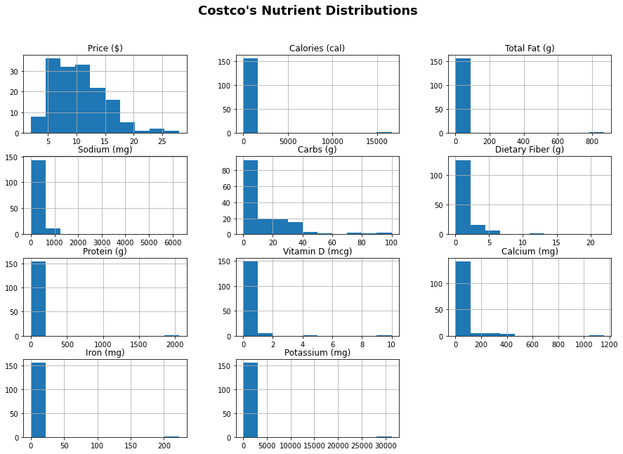

```python
%matplotlib inline
# Show histogram of available values
import matplotlib.pyplot as plt
_ = df1.hist(figsize=(15,10))
#display(h)

_ = plt.suptitle("Costco's Nutrient Distributions", weight='bold', fontsize=18)
```

```python
import seaborn as sns
```

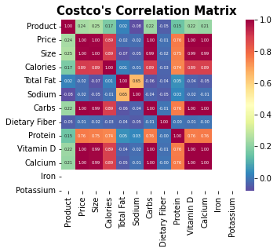

```python
corrmat = df.corr()
hm = sns.heatmap(corrmat,
                 cbar=True,
                 annot=True,
                 square=True,
                 fmt='.2f',
                 annot_kws={'size': 5},
                 yticklabels=df.columns,
                 xticklabels=df.columns,
                 cmap="Spectral_r")
_= plt.title("Costco's Correlation Matrix", weight='bold', fontsize = 15)
```

```python
import scipy
```

```python
scipy.stats.pearsonr(df['Price'], df['Iron'])
```

```
(0.22249363382536577, 0.005243588563045845)
```

```python
scipy.stats.pearsonr(df['Price'], df['Potassium'])
```

```
(0.21425712442218608, 0.007235376703240538)
```

# Optimization

To find the Stigler Diet Solution for Costco's, the same method used to solve the Stigler Diet problem for Safeway and Trader Joe's will be followed; the Primal-Dual Path-Following Method from SciPy library. The minimum constraints are set to be the FDA daily nutritional requirements concerning the nutrients present in Costco's products.

```python
# Minimum nutrients
nutrients = [
    ['Calories (cal)', 3000],
    ['Protein (g)', 50],
    ['Carbs (g)', 300],
    ['Total Fat (g)', 65],
    ['Sodium (mg)', 2400],
    ['Dietary Fiber (g)', 25],
    ['Vitamin D (mcg)', 10],
    ['Calcium (mg)', 1000],
    ['Iron (mg)', 18],
    ['Potassium (mg)', 3500],
]
```

```python
from scipy.optimize import linprog
import numpy as np
```

```python
# get the price array
c = df['Price'].to_numpy()
```

```python
# seperate nutrient columns from data
df_new = df. iloc[:, 3:16]
df_new = df_new.fillna(0)
```

```python
# check that all NA values were changed to 0
if df_new.isna().any().any():
    print("The DataFrame contains NaN values.")
else:
    print("The DataFrame does not contain NaN values.")
```

```
The DataFrame does not contain NaN values.
```

```python
# create an array from the nutrient only columns
A = df_new.to_numpy()
#transpose it so 1 row = 1 nutrition
# end up with 11 rows
A_eq = -np.transpose(A)
```

```python
# daily FDA nutriotional requirements set as minimum
print(len(A_eq))
b_eq = np.array([-3000*7, -65*7, -2400*7, -300*7, -25*7, -50*7, -90*7, -1000*7,-18*7, -3500*7])
```

```
10
```

```python
# result
res = linprog(c, A_eq = A_eq, b_eq = b_eq)
print("Minimum cost of the diet:", res.fun)

# Print the food names, their corresponding non-zero quantities, and their prices
food_names = df['Product'].values
food_prices = df['Price'].values
optimal_quantities = res.x

for name, price, quantity in zip(food_names, food_prices, optimal_quantities):
    if quantity > 1e-6:  # A small threshold to account for floating-point errors
        print(f"{name}: {quantity}, Price: {price}")
```

```
Minimum cost of the diet: 32147.471907512103
10" Egg Wraps (Cage Free Cauliflower): 2.3539092854856007e-06, Price: 8.0
100 % Orange Juice (Bottles): 1.4320720273084395e-06, Price: 12.0
100% Colombian Coffee: 2.5821907704890813e-06, Price: 15.0
100% Juice (Variety Pack): 1.437429479947354e-06, Price: 9.0
3 Cheese Mini Ravioli (Organic) [Organic]: 1.2915891619831965e-06, Price: 10.0
A.1. Steak Sauce (Original): 0.00024016717866577947, Price: 9.0
ABF Turkey Breast ((sold per lb.)): 1.7027366573122999e-06, Price: 3.0
Acai Superfruit Packs: 1.216384857006997e-06, Price: 13.0
All Purpose Flour: 1.359540452712254e-06, Price: 18.0
Almond Milk (Organic Unsweetened Vanilla): 1.435556327397634e-06, Price: 7.0
Almond Milk (Organic Unsweetened): 7.0186207395378615, Price: 8.0
Almond Milk (Original): 1.4318267152414427e-06, Price: 11.0
Altoids (Peppermint): 1.1269459512325228e-05, Price: 14.0
Amarena Wild Cherries: 2.660857448203396e-06, Price: 15.0
Animal Crackers (Organic): 1.0460069073938794e-06, Price: 10.0
Apple Sauce Pouch (Organic) [Organic]: 1.8481365493108906e-06, Price: 10.0
Applesauce (Organic - Variety): 1.8804725774433012e-06, Price: 14.0
Applesauce Cups (Organic) [Organic]: 1.9022489357379482e-06, Price: 15.0
Artichoke Hearts (Quarters & Halves, Marinated in Oil): 63.993404103503934, Price: 9.0
Artisan Italian Dressing (Simply): 0.0005207581864411563, Price: 6.0
Autumn Mix: 1.7706827075595996e-06, Price: 12.0
Avocado Oil (100% Pure): 0.00013250766041782904, Price: 19.0
Bacon (Low Sodium): 1.8872739212647186e-06, Price: 16.0
Bacon Crumbles: 3.991313691166333e-06, Price: 8.0
Bagel Bites (Mozzarella Cheese): 4.182468091948807e-06, Price: 8.0
Baking Soda: 5.594333193892364, Price: 7.0
Balsamic Glaze: 6.647219706129052e-06, Price: 6.0
Balsamic Vinegar: 157.49993305284772, Price: 10.0
Bark Thins (Dark Chocolate Almond): 5.107870100971571, Price: 9.0
Barramundi Fillet (Farm raised previously frozen (sold per lb.)): 2.057705233285258e-06, Price: 9.0
Basmati Rice: 1.3329960129182023e-06, Price: 19.0
Beef Franks: 1.0915435127947633e-06, Price: 9.0
Beef Inside Skirts (USDA Choice (sold per lb.)): 3.634447697403064e-06, Price: 12.0
Berry Blend (Organic Three Berries): 1.4592430247580383e-06, Price: 14.0
Better Than Bouillon (Organic Chicken Base) [Organic]: 4.754660563354861e-06, Price: 5.0
Better Than Bouillon (Organic Vegetable Base) [Organic,Vegan]: 2.425532754058092e-05, Price: 5.0
Better Than Bouillon (Organic Beef Base) [Organic]: 5.035571293992165e-06, Price: 5.0
Biscotti (Almond Dark Chocolate): 1.0759657850081267e-06, Price: 10.0
Black Bean Layer Dip: 3.2564606720946412e-06, Price: 9.0
```

[output cut: 16 more lines]

```
Burger Blends: 20.621665105458046, Price: 10.0
Butter (Organic Salted) [Organic]: 2.1813044988148267e-05, Price: 11.0
Butter (Grass-Fed Salted): 2.4276729243539496e-05, Price: 10.0
Buttery Spread (Original): 1.0468286025864736e-06, Price: 7.0
Cabaret Butter Cracker (5 packs): 2.112574399683629e-06, Price: 7.0
Cacao Powder (Organic): 6.337886469387925, Price: 6.0
Caesar Dressing (Keto Friendly): 0.00030544766875380145, Price: 8.0
Caldo de Pollo: 5.249202069672725e-06, Price: 5.0
Canadian Bacon Slices (Uncured): 2.402374191211047e-06, Price: 9.0
Canned Pumpkin: 4.057524019334492e-06, Price: 6.0
Canola Oil (2, 3 Quarts): 2.105403725869875e-06, Price: 13.0
Caramel Macchiato Creamer: 2.3776138868969584e-05, Price: 7.0
Caramel Stroopwafel (*may not be restocked): 0.00016199071636461104, Price: 8.0
Carrots with Maple Glaze: 1.7035819480440568e-06, Price: 11.0
Caulicious Dip: 2.009244783825436e-06, Price: 7.0
```

### Case Study Trader Joes: Data Scrapping, Levenshtein, Visualization & Optimization

Similar to the retrieval of the Costco price data, a table, last updated the 30th of January 2023, from the website, https://www.simplegrocerydeals.com/trader-joes-price-list/, was used and obtained from Super Grocery Lists: https://supergrocerylists.com/colists/list/288/lookup, using Pandas read html function to scrape the table.

The raw table had 183 rows and 5 columns, the variables contained in the table are Product, Brand, Price, Size and Price per Unit. The list of 183 food products was varied in kind, from food products unique to Trader Joes to general dairy and produce items. After removing the information not relevant to the goals of this project, such as the columns “Brand”, "Size" and "Price per Unit", and cleaning the data, removing any possible NA values, the table had 182 rows and 2 columns.

```python
import pandas as pd

#web scrape table
tab = pd.read_html("https://supergrocerylists.com/colists/list/288/lookup")
#turn scraped table into pandas data-frame
dfP = pd.DataFrame(tab[0])
# drop rows containing NA
dfP = dfP.dropna()

# remove last row contianing "Load More ^"
dfP.drop(dfP.tail(1).index,inplace=True)
dfP = dfP.drop(["Brand", "Size", "Price per Unit"], axis=1)

dfP.to_csv('TraderPrice.csv', index=False)
```

Nutritional data from Trader Joes’ took a lot of time after getting the products' names and price. Since the nutrirional values were not available to download, the full data set of products' nutritional values was gathered manually. Data was Web Scraped from the website nutritionix to gather nutritional data in a spreadsheet. After inputting data manually, the data was classified into Total fat, trans fat, saturated fat, cholesterol, sodium, total carbs, dietary fiber, sugar , vitaminA, vitamin C, Calcium, Iron, and Potassium. Data that was not available were considered to be 0 in the data-sheet. To move on the next step, a final check was done to make sure that each data was measured for a single piece after data collection.

As with Safeway, the Levenshtein Distance was implemented to merge together Trader Joe's product nutritional data and Trader Joe's product price data. The rows for which the products' nutritional values were not available were dropped. To prepare the data for optimization, the nutrient columns that were in the same units of measurement as reported by the FDA daily nutritional requirements for the respective nutrient were kept while the other columns for the same nutrient, but recorded in different units, were dropped. Also dropped were the non-essential nutrients Cholesterol and Sugar. Further, the nutrients recorded as Daily Value percentages were converted to mg or mcg units of measure.

```python
import Levenshtein

#  Using the python-Levenshtein library to calculate the Levenshtein distance.

# Read CSV files
file_F = pd.read_csv('TraderPrice.csv')
file_N = pd.read_csv("Trader Joe's Nutrition.csv")

# replace NA values with 0, here we take the NAs as the product(row) containing 0 of the respective nutrient(column), unless all rows has NA value
file_N = file_N.fillna(0)

# This code will read the CSV files, compare names using the Levenshtein distance,
# Function to find the most similar name
def find_most_similar_name(name_N, names_F, matched_names):
    best_match = None
    best_match_index = None
    min_distance = float('inf')

    for index, name_F in enumerate(names_F):
        if index not in matched_names:
            distance = Levenshtein.distance(name_N, name_F)

            if distance < min_distance:
                min_distance = distance
                best_match = name_F
                best_match_index = index

    return best_match, best_match_index

# Set to keep track of matched names
# keep track of the names that have already been matched in file
# ensure that a name is not matched more than once.

matched_names = set()

# Iterate through each row in file_N
# If a name in file N has a closer match to a name that has already been matched in file F,
# it will skip that name and find the next most similar name in file F that hasn't been matched yet.
for index, row in file_N.iterrows():
    name_N = row['Product']
    most_similar_name_F, most_similar_name_index = find_most_similar_name(name_N, file_F.iloc[:, 0], matched_names)

    # Update matched_names set
    matched_names.add(most_similar_name_F)

    # Append values from file_N to the corresponding row in file_F
    for col in file_N.columns[1:]:
        file_F.loc[file_F.iloc[:, 0] == most_similar_name_F, col] = row[col]

# Save the updated file_F to a new CSV file
file_F.to_csv('TraderJoesNutr_price.csv', index=False)
```

```python
# read in merged data of products and their respective nutritional values
df = pd.read_csv('TraderJoesNutr_price.csv')
#drop NA values from merger
df = df.dropna()
```

```python
# drop $, turn price into float
df['Price'] = df['Price'].str.replace('$', '').astype(float)

# drop columns not relevant to the goals of optimization, such as duplications of nutrients in different units of measure
d_df = df.drop(["Serving size","Total Fat", "Saturated fat", "Saturated Fat(g)", "Trans Fat(g)", "Cholesterol", "Sodium", "Total Carbohydrates", "Dietery Fiber", "Calcium", "Iron", "Potassium", "Sugars(g)", "Cholesterol(mg)"], axis=1)
d_df.head()

# converting string to float, for columns with Daily Value percentage
d_df['Vitamin A'] = d_df['Vitamin A'].str.rstrip('%').astype('float')
d_df['Vitamin C'] = d_df['Vitamin C'].str.rstrip('%').astype('float')

# converting Daily Value percentage into mcg
d_df['Vitamin A'] = d_df['Vitamin A']/100*900
d_df['Vitamin C'] = d_df['Vitamin C']/100*90


#check
d_df.tail(4)
```

|  | Product | Price | Calories | Total Fat(g) | Sodium(mg) | Total Carbohydrates(g) | Dietery Fiber(g) | Protein(g) | Vitamin A | Vitamin C | Calcium(mg) | Iron(mg) | Potassium(mg) |
| --- | --- | --- | --- | --- | --- | --- | --- | --- | --- | --- | --- | --- | --- |
| 178 | Brioche Buns | 3.99 | 280.0 | 9.0 | 440.0 | 44.0 | 3.0 | 6.0 | 54.0 | 0.0 | 0.0 | 0.0 | 0.0 |
| 179 | Brioche Hot Dog Buns | 2.99 | 170.0 | 2.5 | 230.0 | 32.0 | 0.5 | 5.0 | 0.0 | 0.0 | 0.0 | 0.0 | 0.0 |
| 180 | Brioche Toast | 1.99 | 140.0 | 3.5 | 160.0 | 24.0 | 1.0 | 3.0 | 0.0 | 5.4 | 0.0 | 0.0 | 0.0 |
| 181 | British Style Crumpets | 2.99 | 100.0 | 0.0 | 260.0 | 22.0 | 0.5 | 3.0 | 0.0 | 0.0 | 0.0 | 0.0 | 0.0 |

#### Data Visualization

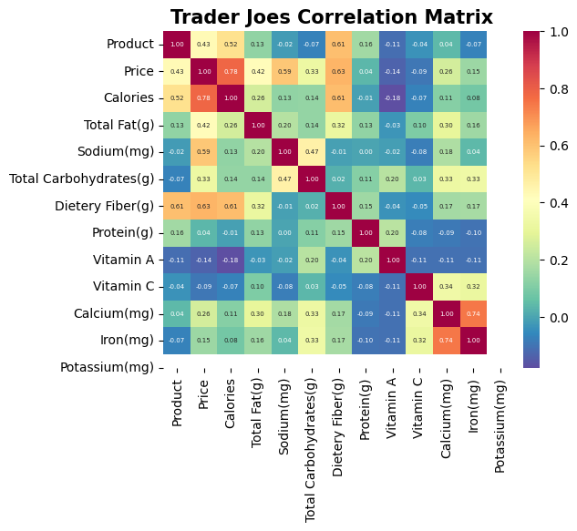

```python
import matplotlib.pyplot as plt
import seaborn as sns
# retrieve correlation between all variables
corrmat = d_df.corr()
hm = sns.heatmap(corrmat,
                 cbar=True,
                 annot=True,
                 square=True,
                 fmt='.2f',
                 annot_kws={'size': 5},
                 yticklabels=d_df.columns,
                 xticklabels=d_df.columns,
                 cmap="Spectral_r")

_= plt.title('Trader Joes Correlation Matrix', weight='bold', fontsize = 15)
```

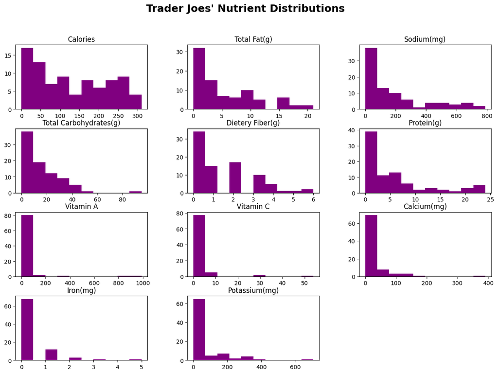

```python
%matplotlib inline

#create histograms for all variables except price
g_df = d_df.loc[:, d_df.columns != "Price"]

# removes array text from output
_ = g_df.hist(figsize=(15,10), grid=False, color='purple')

# title
_ = plt.suptitle("Trader Joes' Nutrient Distributions", weight='bold', fontsize=18)
```

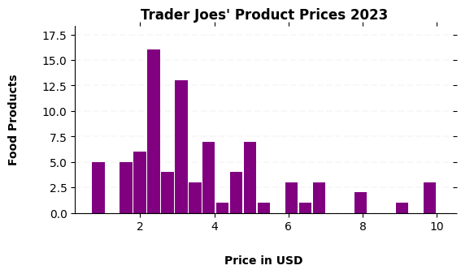

```python
ax = d_df.hist(column='Price', bins=25, grid=False, figsize=(6,3), color='purple', zorder=2, rwidth=0.9)

ax = ax[0]
for x in ax:
    x.spines['right'].set_visible(False)
    x.spines['top'].set_visible(False)

    x.tick_params(axis="both", which="both", bottom="off", top="off", labelbottom="on", left="off", right="off", labelleft="on")
    # Draw horizontal axis lines
    vals = x.get_yticks()
    #
    for tick in vals:  #removes dashed lines from inside histogram
        x.axhline(y=tick, linestyle='dashed', alpha=0.4, color='#eeeeee', zorder=1)
    # Set x-axis label
    x.set_xlabel("Price in USD", labelpad=20, weight='bold', size=10)
    # Set title
    x.set_title("Trader Joes' Product Prices 2023", weight='bold', size=12)
    # Set y-axis label
    x.set_ylabel("Food Products", labelpad=20, weight='bold', size=10)
```

### Optimization

To find the Stigler Diet Solution for Trader Joes' the same method used to solve the Stigler Diet problem for Safeway will be followed; the Primal-Dual Path-Following Method from SciPy library. The minimum constraints are set to be the FDA daily nutritional requirements concerning the nutrients present in the Trader Joes' products.

```python
# list of Nutrients and their recommeneded daily intake amount for reference
nutrients = pd.DataFrame([
    ['Calories(cal)', 3000],
    ['Total Fat (g)', 65],
    ['Sodium (mg)', 2400],
    ['Total Carbohydrates (g)', 300],
    ['Dietery Fiber (g)', 25],
    ['Protein (g)', 50],
    ['Vitamin A (mcg)', 900],
    ['Vitamin C (mg)', 90],
    ['Calcium (mg)', 1000],
    ['Iron (mg)', 18],
    ['Potassium (mg)', 3500],
])
```

```python
from scipy.optimize import linprog
import numpy as np
```

```python
# get the price array
c = d_df['Price'].to_numpy()
```

```python
# seperate nutrient columns from data
df_new = d_df. iloc[:, 2:16]
df_new.tail()
```

|  | Calories | Total Fat(g) | Sodium(mg) | Total Carbohydrates(g) | Dietery Fiber(g) | Protein(g) | Vitamin A | Vitamin C | Calcium(mg) | Iron(mg) | Potassium(mg) |
| --- | --- | --- | --- | --- | --- | --- | --- | --- | --- | --- | --- |
| 174 | 260.0 | 15.0 | 480.0 | 18.0 | 0.0 | 13.0 | 0.0 | 0.0 | 0.0 | 0.0 | 0.0 |
| 178 | 280.0 | 9.0 | 440.0 | 44.0 | 3.0 | 6.0 | 54.0 | 0.0 | 0.0 | 0.0 | 0.0 |
| 179 | 170.0 | 2.5 | 230.0 | 32.0 | 0.5 | 5.0 | 0.0 | 0.0 | 0.0 | 0.0 | 0.0 |
| 180 | 140.0 | 3.5 | 160.0 | 24.0 | 1.0 | 3.0 | 0.0 | 5.4 | 0.0 | 0.0 | 0.0 |
| 181 | 100.0 | 0.0 | 260.0 | 22.0 | 0.5 | 3.0 | 0.0 | 0.0 | 0.0 | 0.0 | 0.0 |

```python
# create an array from the nutrient only columns
A = df_new.to_numpy()
#transpose it so 1 row = 1 nutrition
# end up with 11 rows
A_eq = -np.transpose(A)
```

```python
# daily FDA nutriotional requirements set as minimum
print(len(A_eq))
b_eq = np.array([-3000*7, -65*7, -2400*7, -300*7, -25*7, -50*7, -900*7, -90*7, -1000*7,-18*7, -3500*7])
```

```
11
```

```python
# result
res = linprog(c, A_eq = A_eq, b_eq = b_eq)
print("Minimum cost of the diet:", res.fun)

# Print the food names, their corresponding non-zero quantities, and their prices
food_names = d_df['Product'].values
food_prices = d_df['Price'].values
optimal_quantities = res.x

for name, price, quantity in zip(food_names, food_prices, optimal_quantities):
    if quantity > 1e-6:  # A small threshold to account for floating-point errors
        print(f"{name}: {quantity}, Price: {price}")
```

```
Minimum cost of the diet: 2635.3337534906927
Aioli Garlic Mustard Sauce: 38.80540363905899, Price: 2.49
Almond Breeze (Unsweetened Original): 8.49420762758513, Price: 2.19
Apple & Strawberry Fruit Bar (Dried Fruit): 6.309810141732026, Price: 0.99
Apple Apricot Dried Fruit Bar (Dried Bar): 18.181818181818183, Price: 0.69
Apple Juice (Organic) [Organic]: 709.8104772285744, Price: 2.99
Artichoke Antipasto: 6.108956646475356, Price: 2.49
Artichoke Timbales: 6.363636363636363, Price: 4.99
Baby Red Butter Lettuce & Baby Spinach Blend (Organic) [Organic]: 53.10003938924605, Price: 2.29
Balsamic Vinegar (of Modena): 66.8504841957851, Price: 2.29
Big Soft Pretzels: 9.767246383667478, Price: 2.49
Black Bean Quinoa Tortilla Chips: 10.032674837840421, Price: 3.29
```

### Conclusion

The previous result alligns with the distributions and correlations between varaibles and price seen in the previous graphs, one needs a lot of one item to achieve the daily nutritional requirements, for example 53 bags of Baby Red Butter Lettuce. This is most likely due to the varied food items scrapped from the website which included items such as spices and ice cream. This study successfully demonstrates we can approach to solving the Stigler Diet problem by combining modern data scraping techniques, the Levenshtein distance for string matching, and the primal-dual path-following method for linear optimization. By incorporating real-time food prices and comprehensive nutritional information, the proposed solution better reflects the actual dietary needs and cost considerations of individuals. However, it is essential to note that this study's approach is still limited by certain factors, such as missing price information, the reliance on manual data fetching (even if automated), and most importantly, the limitations of the monotone Stigler Diet. Future considerations could focus on refining the data collection process, incorporating additional factors like taste preferences and cultural influences, using a condorcet voting system along with the Levenshtein Distance, and extending the method to account for other essential nutrients or non-nutrient factors in a healthy diet.

### References

Levenshtein Distance

https://rosettacode.org/wiki/Levenshtein_distance

http://www.ics.uci.edu/~dan/pubs/p341-hirschberg.pdf

Linear Optimization: The Primal-Dual Path-Following Method

https://docs.scipy.org/doc/scipy/reference/generated/scipy.optimize.linprog.html

https://www.stat.cmu.edu/~ryantibs/convexopt-S15/lectures/16-primal-dual.pdf

https://www.numerical.rl.ac.uk/people/nimg/course/lectures/raphael/lectures/lec16slides.pdf